# Grab ‘Safety’ Challenge

Bernardus Ari Kuncoro

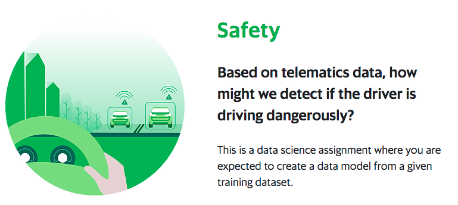

# Problem Description

Given the telematics data for each trip and the label if the trip is tagged as dangerous driving, derive a model that can detect dangerous driving trips.

# Dataset

The given dataset contains telematics data during trips (bookingID). Each trip will be assigned with label 1 or 0 in a separate label file to indicate dangerous driving. Field

**Data Dictionary**

- bookingID: trip id
- Accuracy: accuracy inferred by GPS in meters
- Bearing: GPS bearing in degree
- acceleration_x: accelerometer reading at x axis (m/s2)
- acceleration_y: accelerometer reading at y axis (m/s2)
- acceleration_z: accelerometer reading at z axis (m/s2)
- gyro_x: gyroscope reading in x axis (rad/s)
- gyro_y: gyroscope reading in y axis (rad/s)
- gyro_z: gyroscope reading in z axis (rad/s)
- second: time of the record by number of seconds
- Speed: speed measured by GPS in m/s

# 1. Loading Library

```r
library(tidyverse) #for data preparation
library(DataExplorer) #for exploratory data analysis
library(caret) # for machine learning libraries
```

# 2. Loading Dataset

**Feature**

```r
options(scipen=999) # avoid scientific format in R
part_0 <- read.csv("dataset/safety/features/part-00000-e6120af0-10c2-4248-97c4-81baf4304e5c-c000.csv")
part_1 <- read.csv("dataset/safety/features/part-00001-e6120af0-10c2-4248-97c4-81baf4304e5c-c000.csv")
part_2 <- read.csv("dataset/safety/features/part-00002-e6120af0-10c2-4248-97c4-81baf4304e5c-c000.csv")
part_3 <- read.csv("dataset/safety/features/part-00003-e6120af0-10c2-4248-97c4-81baf4304e5c-c000.csv")
part_4 <- read.csv("dataset/safety/features/part-00004-e6120af0-10c2-4248-97c4-81baf4304e5c-c000.csv")
part_5 <- read.csv("dataset/safety/features/part-00005-e6120af0-10c2-4248-97c4-81baf4304e5c-c000.csv")
part_6 <- read.csv("dataset/safety/features/part-00006-e6120af0-10c2-4248-97c4-81baf4304e5c-c000.csv")
part_7 <- read.csv("dataset/safety/features/part-00007-e6120af0-10c2-4248-97c4-81baf4304e5c-c000.csv")
part_8 <- read.csv("dataset/safety/features/part-00008-e6120af0-10c2-4248-97c4-81baf4304e5c-c000.csv")
part_9 <- read.csv("dataset/safety/features/part-00009-e6120af0-10c2-4248-97c4-81baf4304e5c-c000.csv")
```

# 3. Data Preparation

All features must be united into one dataframe

```r
feature_all <- do.call("rbind", list(part_0,part_1,part_2,part_3,part_4,part_5,part_6,part_7,part_8,part_9))
```

Remove the part_0 to part_9 dataframe to save memory

```r
rm(part_0,part_1,part_2,part_3,part_4,part_5,part_6,part_7,part_8,part_9)
```

Let’s check the dimension of feature_all

```r
dim(feature_all)
```

```
[1] 16135561       11
```

**Label**

```r
label <- read.csv("dataset/safety/labels/part-00000-e9445087-aa0a-433b-a7f6-7f4c19d78ad6-c000.csv")
```

Now let’s check the dimension of the label.

```r
dim(label)
```

```
[1] 20018     2
```

Check whether the bookingID is unique.

```r
label2 <- label %>% group_by(bookingID) %>% summarise(n=n()) %>% filter(n>1)
dim(label2)
```

```
[1] 18  2
```

There are 18 unique Booking IDs are duplicate. Let’s check the label of those 18 unique booking IDs.

```r
check_label <- label2 %>% left_join(label,by="bookingID")
check_label
```

| bookingID | n | label |
| --- | --- | --- |
| 13 | 2 | 0 |
| 13 | 2 | 1 |
| 154618822837 | 2 | 1 |
| 154618822837 | 2 | 0 |
| 223338299461 | 2 | 0 |
| 223338299461 | 2 | 1 |
| 395136991308 | 2 | 1 |
| 395136991308 | 2 | 0 |
| 403726925929 | 2 | 0 |
| 403726925929 | 2 | 1 |

[output cut: 26 more lines]

All of the label has two options of 0 or 1. So, we just need to drop them.

```r
label_final <- label %>% anti_join(label2)
head(label_final)
```

|  | bookingID | label |
| --- | --- | --- |
| 1 | 111669149733 | 0 |
| 2 | 335007449205 | 1 |
| 3 | 171798691856 | 0 |
| 4 | 1520418422900 | 0 |
| 5 | 798863917116 | 0 |
| 6 | 283467841567 | 0 |

Check the proportion of the label: 75% labeled as 0, 25% labeled as 1.

```r
prop.table(table(label_final$label))
```

```
        0         1
0.7506256 0.2493744
```

Remove some dataframe to save memory

# 4. Feature Engineering

We should think creatively, what would be the features whether a booking id is labeled as safe or not. Not Safe = 1, Safe = 0.

```r
# Perform undersampling first. Just use 50% class 0 and 50% class 1

# rows that have "z" and "zz" entries
z_ind <- which(label_final$label == 0)
zz_ind <- which(label_final$label == 1)

nsamp <- min(length(z_ind), length(zz_ind))   #number of elements to sample

## select `nsamp` entries with 0 and `nsamp` entries with 1
pick_z <- sample(z_ind, nsamp)
pick_zz <- sample(zz_ind, nsamp)
label_final_new <- label_final[c(pick_z, pick_zz), ]

# We need to order by time of each bookingID for undersampling features.
feature_all_1 <- label_final_new %>% left_join(feature_all, by='bookingID') %>%
  group_by(bookingID) %>% arrange(second, .by_group=TRUE)

# Average speed, Median, Max Speed, Duration of Booking
candidate_feature_1 <- feature_all_1 %>% group_by(bookingID) %>%
  summarise(avg_speed=mean(Speed), median_speed=median(Speed), max_speed=max(Speed), duration=max(second), sd_speed=sd(Speed))

# Delta Bearing: Average delta bearing, Max delta bearing, Median delta bearing
candidate_feature_2 <- feature_all_1 %>% select(bookingID,Bearing) %>%
  mutate(lag_bearing=lag(Bearing),delta_bearing=abs(Bearing-lag_bearing)) %>%
  filter(!is.na(delta_bearing)) %>% group_by(bookingID) %>%
  summarise(avg_delta_bearing=mean(delta_bearing),
                                    max_delta_bearing=max(delta_bearing),
                                    median_delta_bearing= median(delta_bearing),
                                    sd_delta_bearing=sd(delta_bearing))

# Acceleration: Average acceleration, median acceleration, max acceleration
candidate_feature_3 <- feature_all_1 %>%
  select(bookingID, acceleration_x,acceleration_y, acceleration_z) %>%
  group_by(bookingID) %>% summarise(avg_acceleration_x=mean(acceleration_x),
                                    avg_acceleration_y=mean(acceleration_y),
                                    avg_acceleration_z=mean(acceleration_z),
                                    median_acceleration_x=median(acceleration_x),
                                    median_acceleration_y=median(acceleration_y),
                                    median_acceleration_z=median(acceleration_z),
                                    max_acceleration_x=max(acceleration_x),
                                    max_acceleration_y=max(acceleration_y),
                                    max_acceleration_z=max(acceleration_z),
                                    sd_acceleration_x=sd(acceleration_x),
                                    sd_acceleration_y=sd(acceleration_y),
                                    sd_acceleration_z=sd(acceleration_z))

# Gyro: average gyroscope, median gyro, max gyro
candidate_feature_4 <- feature_all_1 %>%
  select(bookingID, gyro_x, gyro_y, gyro_z) %>% group_by(bookingID) %>%
  summarise(avg_gyro_x=mean(gyro_x),
            avg_gyro_y=mean(gyro_y),
            avg_gyro_z=mean(gyro_z),
            median_gyro_x=median(gyro_x),
            median_gyro_y=median(gyro_y),
            median_gyro_z=median(gyro_z),
            max_gyro_x=max(gyro_x),
            max_gyro_y=max(gyro_y),
            max_gyro_z=max(gyro_z),
            sd_gyro_x=sd(gyro_x),
            sd_gyro_y=sd(gyro_y),
            sd_gyro_z=sd(gyro_z))

# Delta Acceleration: Average Delta acceleration, median delta acceleration, max delta acceleration, and standard deviation
candidate_feature_5 <- feature_all_1 %>%
  select(bookingID, acceleration_x,acceleration_y, acceleration_z) %>%
  mutate(lag_acceleration_x=lag(acceleration_x),
         lag_acceleration_y=lag(acceleration_y),
         lag_acceleration_z=lag(acceleration_z)) %>%
  mutate(delta_accel_x = abs(lag_acceleration_x-acceleration_x),
         delta_accel_y = abs(lag_acceleration_y-acceleration_y),
         delta_accel_z = abs(lag_acceleration_z-acceleration_z)) %>%
  filter(!is.na(delta_accel_x)) %>% group_by(bookingID) %>%
  summarise(avg_delta_accel_x=mean(delta_accel_x),
            avg_delta_accel_y=mean(delta_accel_y),
            avg_delta_accel_z=mean(delta_accel_z),
            max_delta_accel_x=max(delta_accel_x),
            max_delta_accel_y=max(delta_accel_y),
            max_delta_accel_z=max(delta_accel_y),
            median_delta_accel_x=median(delta_accel_x),
            median_delta_accel_y=median(delta_accel_y),
            median_delta_accel_z=median(delta_accel_z),
            sd_delta_accel_x=sd(delta_accel_x),
            sd_delta_accel_y=sd(delta_accel_y),
            sd_delta_accel_z=sd(delta_accel_z))

# Delta Gyro: Average Delta gyro, median delta gyro, max delta gyro, and standard deviation gyro
candidate_feature_6 <- feature_all_1 %>%
  select(bookingID, gyro_x,gyro_y, gyro_z) %>%
  mutate(lag_gyro_x=lag(gyro_x),
         lag_gyro_y=lag(gyro_y),
         lag_gyro_z=lag(gyro_z)) %>%
  mutate(delta_gyro_x = abs(lag_gyro_x-gyro_x),
         delta_gyro_y = abs(lag_gyro_y-gyro_y),
         delta_gyro_z = abs(lag_gyro_z-gyro_z)) %>%
  filter(!is.na(delta_gyro_x)) %>% group_by(bookingID) %>%
  summarise(avg_delta_gyro_x=mean(delta_gyro_x),
            avg_delta_gyro_y=mean(delta_gyro_y),
            avg_delta_gyro_z=mean(delta_gyro_z),
            max_delta_gyro_x=max(delta_gyro_x),
            max_delta_gyro_y=max(delta_gyro_y),
            max_delta_gyro_z=max(delta_gyro_y),
            median_delta_gyro_x=median(delta_gyro_x),
            median_delta_gyro_y=median(delta_gyro_y),
            median_delta_gyro_z=median(delta_gyro_z),
            sd_delta_gyro_x=sd(delta_gyro_x),
            sd_delta_gyro_y=sd(delta_gyro_y),
            sd_delta_gyro_z=sd(delta_gyro_z))

# Combine all the feature candidates into one dataframe
feature_all_final <- candidate_feature_1 %>%
  left_join(candidate_feature_2, by='bookingID') %>%
  left_join(candidate_feature_3, by='bookingID') %>%
  left_join(candidate_feature_4, by='bookingID') %>%
  left_join(candidate_feature_5, by='bookingID') %>%
  left_join(candidate_feature_6, by='bookingID') %>%
  left_join(label_final_new, by='bookingID')
```

Check total feature + label final dimension

```r
dim(feature_all_final)
```

```
[1] 9966   59
```

# 5. Modeling

```r
class(sample_test)
```

```
[1] "data.frame"
```

Check the proportion of train and test label

```r
table(sample_train$label)
```

```
NotSafe    Safe
   3748    3726
```

```r
table(sample_test$label)
```

```
NotSafe    Safe
   1235    1257
```

Fit the training control

```r
fitControl <- trainControl(
  method = 'cv',                   # k-fold cross validation
  number = 5,                      # number of folds
  savePredictions = 'final',       # saves predictions for optimal tuning parameter
  classProbs = T,                  # should class probabilities be returned
  summaryFunction=twoClassSummary  # results summary function
)
```

Model Options

```r
modelnames <- paste(names(getModelInfo()), collapse=',  ')
modelnames
```

```
[1] "ada,  AdaBag,  AdaBoost.M1,  adaboost,  amdai,  ANFIS,  avNNet,  awnb,  awtan,  bag,  bagEarth,  bagEarthGCV,  bagFDA,  bagFDAGCV,  bam,  bartMachine,  bayesglm,  binda,  blackboost,  blasso,  blassoAveraged,  bridge,  brnn,  BstLm,  bstSm,  bstTree,  C5.0,  C5.0Cost,  C5.0Rules,  C5.0Tree,  cf…
```

**Using glm, glmnet, and gbm**

```r
model_glm
```

```
Generalized Linear Model

7474 samples
  57 predictor
   2 classes: 'NotSafe', 'Safe'

No pre-processing
Resampling: Cross-Validated (5 fold)
Summary of sample sizes: 5980, 5980, 5978, 5979, 5979
Resampling results:

  ROC        Sens       Spec
  0.6699218  0.6056655  0.6221156
```

```r
model_glmnet
```

```
glmnet

7474 samples
  57 predictor
   2 classes: 'NotSafe', 'Safe'

No pre-processing
Resampling: Cross-Validated (5 fold)
Summary of sample sizes: 5980, 5978, 5979, 5980, 5979
Resampling results across tuning parameters:

  alpha  lambda         ROC        Sens       Spec
  0.100  0.00007866313  0.6570320  0.5984491  0.6057434
  0.100  0.00036512191  0.6570611  0.5981818  0.6057434
  0.100  0.00169474585  0.6574864  0.6016527  0.6084290
  0.100  0.00786631378  0.6563025  0.6035162  0.6084283
  0.100  0.03651219586  0.6526043  0.5939133  0.6078885
  0.325  0.00007866313  0.6571530  0.6000513  0.6057430
  0.325  0.00036512191  0.6571458  0.5971147  0.6052065
  0.325  0.00169474585  0.6572761  0.5995165  0.6070878
  0.325  0.00786631378  0.6561952  0.6016477  0.6092330
  0.325  0.03651219586  0.6465780  0.5992481  0.5942030
  0.550  0.00007866313  0.6568054  0.5997850  0.6073548
  0.550  0.00036512191  0.6572485  0.5989818  0.6054746
  0.550  0.00169474585  0.6571910  0.5992498  0.6052093
  0.550  0.00786631378  0.6553514  0.6027183  0.6078896
  0.550  0.03651219586  0.6375761  0.6021835  0.5866826
  0.775  0.00007866313  0.6569525  0.6003186  0.6076226
  0.775  0.00036512191  0.6572289  0.5992481  0.6068161
  0.775  0.00169474585  0.6570932  0.6008495  0.6062810
  0.775  0.00786631378  0.6544413  0.6061846  0.6078892
  0.775  0.03651219586  0.6218676  0.5899090  0.5668222
  1.000  0.00007866313  0.6568221  0.6032527  0.6068176
  1.000  0.00036512191  0.6571909  0.5989807  0.6049391
  1.000  0.00169474585  0.6569871  0.6013821  0.6089649
  1.000  0.00786631378  0.6532756  0.6051169  0.6030592
  1.000  0.03651219586  0.6204119  0.5987105  0.5606510

ROC was used to select the optimal model using the largest value.
The final values used for the model were alpha = 0.1 and lambda = 0.001694746.
```

```r
model_gbm
```

```
Stochastic Gradient Boosting

7474 samples
  57 predictor
   2 classes: 'NotSafe', 'Safe'

No pre-processing
Resampling: Cross-Validated (5 fold)
Summary of sample sizes: 5979, 5979, 5980, 5979, 5979
Resampling results across tuning parameters:

  interaction.depth  n.trees  ROC        Sens       Spec
  1                   50      0.7154017  0.6051154  0.6867863
  1                  100      0.7220983  0.6237935  0.6859892
  1                  150      0.7242106  0.6331347  0.6873264
  1                  200      0.7237940  0.6272591  0.6806161
  1                  250      0.7233680  0.6344652  0.6792738
  2                   50      0.7211375  0.6248612  0.6819609
  2                  100      0.7223574  0.6323300  0.6814236
  2                  150      0.7218321  0.6357992  0.6800810
  2                  200      0.7213682  0.6368623  0.6706897
  2                  250      0.7195941  0.6363268  0.6663958
  3                   50      0.7215647  0.6328659  0.6771297
  3                  100      0.7210040  0.6355332  0.6677367
  3                  150      0.7193791  0.6296637  0.6696162
  3                  200      0.7172180  0.6325996  0.6658585
  3                  250      0.7145775  0.6285967  0.6647851
  4                   50      0.7227561  0.6395364  0.6782072
  4                  100      0.7223905  0.6406024  0.6706875
  4                  150      0.7206369  0.6440698  0.6615600
  4                  200      0.7191310  0.6366031  0.6674632
  4                  250      0.7167689  0.6398024  0.6666603
  5                   50      0.7234821  0.6368680  0.6795455
  5                  100      0.7205589  0.6355357  0.6739094
  5                  150      0.7173859  0.6376652  0.6682739
  5                  200      0.7154429  0.6403325  0.6629080
  5                  250      0.7129925  0.6328641  0.6521683

Tuning parameter 'shrinkage' was held constant at a value of 0.1
Tuning parameter
 'n.minobsinnode' was held constant at a value of 10
ROC was used to select the optimal model using the largest value.
The final values used for the model were n.trees = 150, interaction.depth = 1, shrinkage = 0.1
 and n.minobsinnode = 10.
```

# 6. Evaluation with Testing data for GBM

Since the best ROC among glmnet, glm, and gbm was achieved byu GBM with 72%, then we will use GBM for evaluation.

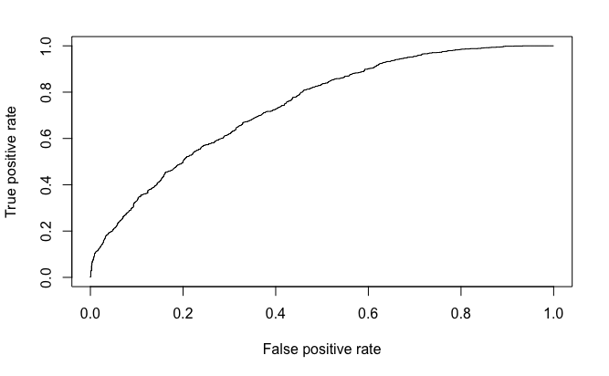

The Area Under curve for testing: 74%. Slightly better than the training data above.

```r
auc@y.values[[1]]
```

```
[1] 0.741971
```